# Partially observed functional data

Hyunsung Kim

2021-02-08

# Simulation 1

## Simulation settings

> Lin, Z., & Wang, J. L. (2020). Mean and covariance estimation for functional snippets. Journal of the American Statistical Association, 1-13.
- 위 논문의 5장에서 $\text{cov I}, n=200, \delta=0.25, \text{SNR}=2$인 경우를 활용하였으며, $N=100$번 반복시행
- 기존 모형과 outlier를 추가하였을 때의 차이를 확인 (outlier 비율은 0.2라 가정)
- Variance $\sigma_X^2$과 covariance $C$의 estimation performance를 비교

## Outliers settings

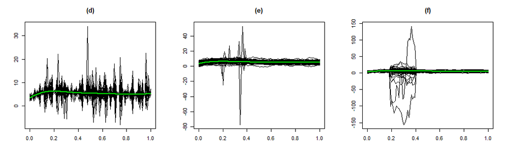

## Original model

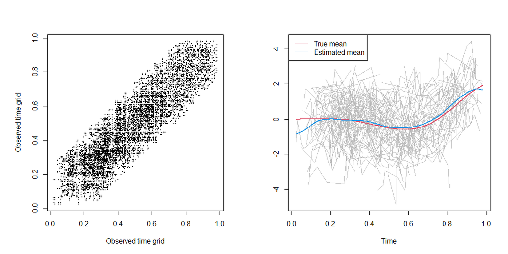

Figure 1. Design plot (Left) and sample trajectories with mean curve (Right).

## Outliers

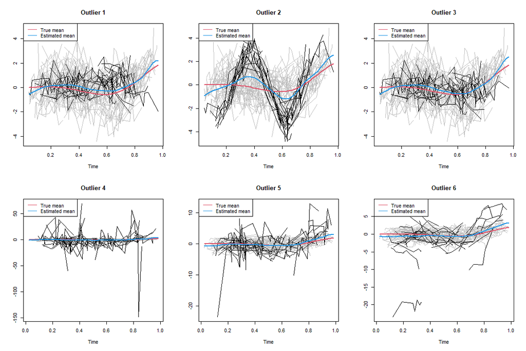

Figure 2. Sample trajectories with outliers and estimated mean curves.

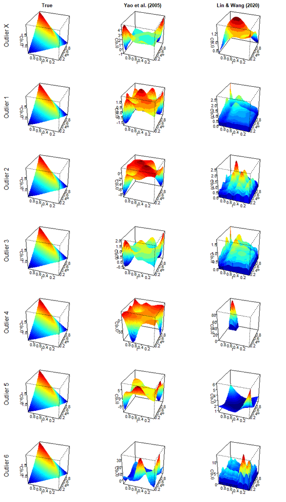

Figure 3. True covariance surface and estimated covariance surfaces.

Table 1. Average RMISE (standard error) of variances($\hat{\sigma}_X^2$) and covariances($\hat{\mathbf{C}}$) estimation.

|  | $N$ | $\hat{\sigma}_X^2$ Yao (2005) | $\hat{\sigma}_X^2$ Lin (2020) | $\hat{\mathbf{C}}$ Yao (2005) | $\hat{\mathbf{C}}$ Lin (2020) |
| --- | --- | --- | --- | --- | --- |
| Outlier X | 100 | 0.81(0.2) | 0.76(0.18) | 1.01(0.98) | 0.49(0.1) |
| Outlier 1 | 100 | 0.82(0.35) | 0.74(0.27) | 1.13(1.9) | 0.49(0.09) |
| Outlier 2 | 100 | 0.72(0.25) | 0.66(0.16) | 2.25(4.06) | 0.45(0.09) |
| Outlier 3 | 100 | 0.83(0.19) | 0.76(0.16) | 1.07(1.74) | 0.52(0.1) |
| Outlier 4 | 96 | 15.44(601.33) | 56.99(9921.84) | 76.38(37358.62) | 22.8(1591.91) |
| Outlier 5 | 84 | 72.87(27277.8) | 253.1(384881.03) | 459.55(815719.51) | 79.56(38005.12) |
| Outlier 6 | 95 | 428.17(571120.25) | 466.96(727089.96) | 1760.77(20018876.64) | 192.22(128639.77) |

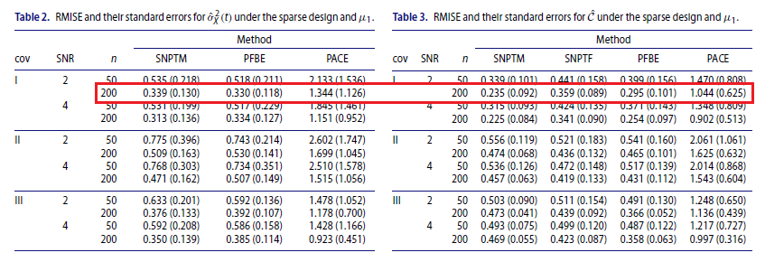

# Simulation 2

## Simulation settings

> Delaigle, A., Hall, P., Huang, W., & Kneip, A. (2020). Estimating the Covariance of Fragmented and Other Related Types of Functional Data. Journal of the American Statistical Association, 1-19.
- 위 논문의 5장에서 Model 2, $n=100$인 경우 활용하였으며, $N=100$번 반복시행
- 기존 모형과 outlier를 추가하였을 때의 차이를 확인 (outlier 비율은 0.2라 가정)
- Variance $\sigma_X^2$과 covariance $C$의 estimation performance를 비교
- Covariance의 intrapolation($\mathcal{D}_0$)과 extrapolation($\mathcal{S}_0 \backslash \mathcal{D}_0$) parts를 비교

## Outliers settings

- **Outlier 1~3**

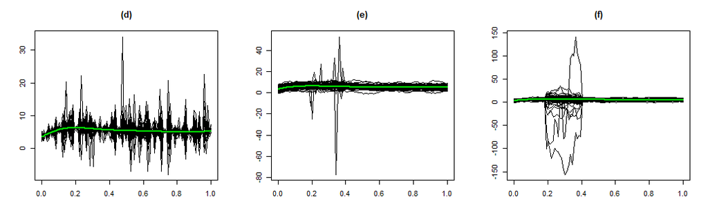

## Original model

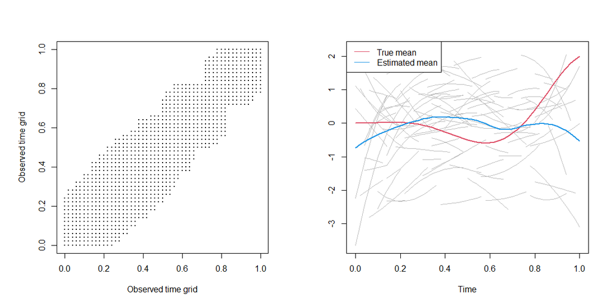

Figure 4. Design plot (Left) and sample trajectories with mean curve (Right).

## Outliers

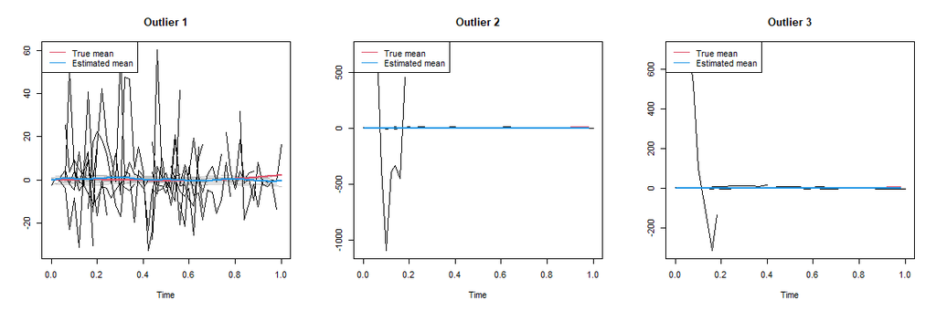

Figure 5. Sample trajectories with outliers and estimated mean curves.

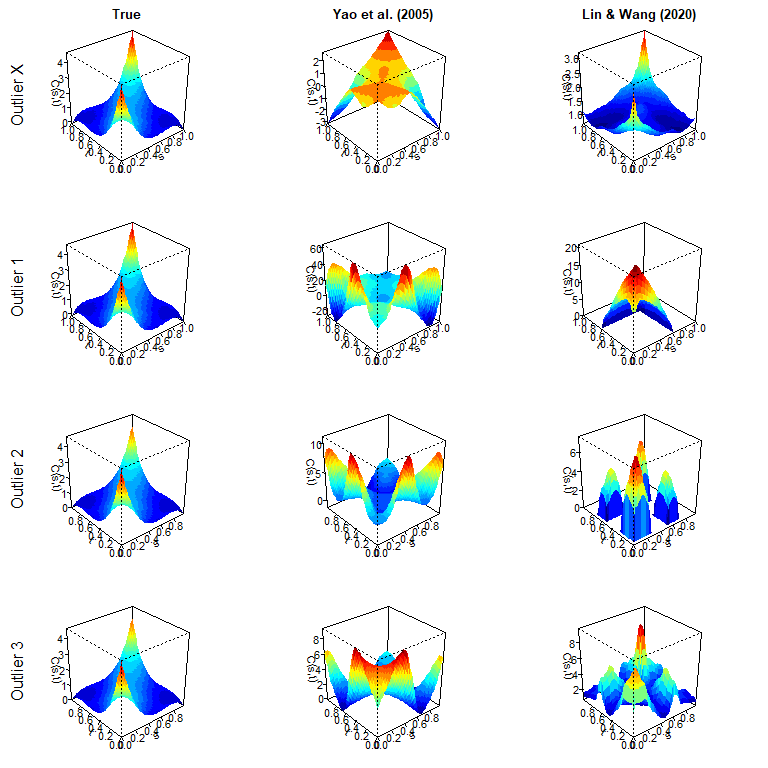

Figure 6. True covariance surface and estimated covariance surfaces.

Table 2. Average RMISE (standard error) of variances($\hat{\sigma}_X^2$) and covariances($\hat{\mathbf{C}}$) estimation.

|  | $N$ | $\hat{\sigma}_X^2$ Yao (2005) | $\hat{\sigma}_X^2$ Lin (2020) | $\hat{\mathbf{C}}$ Yao (2005) | $\hat{\mathbf{C}}$ Lin (2020) |
| --- | --- | --- | --- | --- | --- |
| Outlier X | 100 | 0.85(0.57) | 0.78(0.54) | 1.25(1.52) | 0.64(0.29) |
| Outlier 1 | 97 | 12.65(569.6) | 48.31(6840.72) | 118.23(102985.33) | 19.53(980.85) |
| Outlier 2 | 88 | 14.37(838.99) | 67.16(30458.82) | 105.16(64561.57) | 30.35(5855.69) |
| Outlier 3 | 94 | 571.04(2146606.75) | 901.21(6206631.58) | 7492.98(519413635.06) | 448.62(1476226.4) |

Table 3. Average MISE (standard error) of covariance estimation between intrapolation($\mathcal{D}_0$) and extrapolation($\mathcal{S}_0 \backslash \mathcal{D}_0$) parts.

|  | $N$ | $\mathcal{D}_0$ Yao (2005) | $\mathcal{D}_0$ Lin (2020) | $\mathcal{S}_0 \backslash \mathcal{D}_0$ Yao (2005) | $\mathcal{S}_0 \backslash \mathcal{D}_0$ Lin (2020) |
| --- | --- | --- | --- | --- | --- |
| Outlier X | 100 | 0.18(0.14) | 0.12(0.09) | 1.39(1.49) | 0.29(0.24) |
| Outlier 1 | 97 | 65.59(216.21) | 352.2(892.13) | 13913.76(102977.08) | 29.18(105.91) |
| Outlier 2 | 88 | 84.09(308.49) | 903.48(5841.3) | 10975.05(64319.09) | 17.59(53.11) |
| Outlier 3 | 94 | 726307.97(5896285.81) | 191087.74(1400817.71) | 55418500.87(513593426.81) | 10171.69(75891.03) |

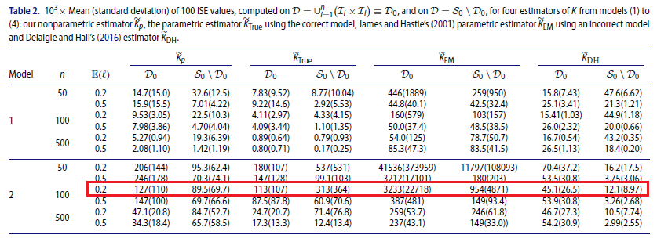